# Task 5

Oleg Arnaut

2023-11-26

# Инструкции

Ниже приведены семь клинических гипотез. В качестве задания протестируйте их, используя соответствующие статистические критерии. Решение должно содержать все элементы алгоритма проверки статистических гипотез:

• Сформулируете нулевую и альтернативную гипотезы. • Укажите уровень значимости α. • Определите статистический тест (критерий) для проверки гипотезы. При необходимости аргументируйте выбор одностороннего теста. • Укажите критическое значение статистики (используйте распределения из материалов лекции). • Определите наблюдаемое значение статистики. • Оцените статистическую значимость (p-value и/или доверительный интервал). • Оцените практическую значимость.

*Данные для анализа необходимо генерировать самостоятельно в соответствии с каждой представленной гипотезой. По возможности используйте пакет dplyr

# Гипотеза 1. Существует ассоциация между уровнем физической активности (бинарная переменная, физическая активность может быть ‘высокой’ и ‘низкой’) и частотой возникновения сердечно-сосудистых заболеваний у пациентов старше 50 лет. Попробуйте вариант с большими выборками (sample_size <- 100). Как изменится стратегия при малых выборках (sample_size <- 30) ?

## Генерация данных

```r
# Воспроизводимость результатов
set.seed(42)

# Общий размер выборки
sample_size <- 100

# Генерация данных по физической активности (бинарная переменная) в фиксированном соотношении 1:1
activity <- factor(sample(c("высокая", "низкая"), sample_size, replace = TRUE, prob = c(0.5, 0.5)))

# Генерация данных по наличию сердечно-сосудистых заболеваний (бинарная переменная)
# У активных людей меньше вероятность заболеть (0.5 vs 0.6)
cardio <- rbinom(sample_size, 1, ifelse(activity == "высокая", 0.5, 0.6))

# Создаем df
data <- data.frame(Физическая_Активность = activity, Сердечно_Сосудистые_Заболевания = cardio)


head(data)
```

```
##   Физическая_Активность Сердечно_Сосудистые_Заболевания
## 1               высокая                               1
## 2               высокая                               0
## 3                низкая                               1
## 4               высокая                               0
## 5               высокая                               1
## 6               высокая                               1
```

## Решение

```r
# H0: Нет ассоциации между уровнем физической активности и частотой возникновения сердечно-сосудистых заболеваний у пациентов старше 50 лет.
# H1: Существует ассоциация между уровнем физической активности и частотой возникновения сердечно-сосудистых заболеваний у пациентов старше 50 лет.
# Уровень значимости: 0.05.
alpha = 0.05
# Выбор стат теста: Стат тест для проверки независимости распределений, подходящий проблеме -- Хи квадрат. При малых размерах выборки использование критерия хи-квадрат может быть нецелесообразно из-за малого ожидаемого количества наблюдений в каждой ячейке таблицы сопряженности. В таких случаях рекомендуется использовать точный тест Фишера.

# Критическое значение: при уровне значимости и степенях свободы 1 равно 3.841
critical_value = 3.841
print(paste("Критическое значение:", critical_value))
```

```
## [1] "Критическое значение: 3.841"
```

```r
# Используем тест
chi_test <- chisq.test(data$Физическая_Активность, data$Сердечно_Сосудистые_Заболевания)

# Сравнение наблюдаемого значения статистики с критическим значением
statistic = chi_test$statistic
if (statistic > critical_value) {
  print("Наблюдаемое значение статистики выше критического, отвергаем нулевую гипотезу. Оно равно:")
} else {
  print("Наблюдаемое значение статистики ниже критического, не отвергаем нулевую гипотезу. Оно равно:")
}
```

```
## [1] "Наблюдаемое значение статистики ниже критического, не отвергаем нулевую гипотезу. Оно равно:"
```

```r
print(statistic)
```

```
##  X-squared
## 0.04208754
```

```r
# Оценка статистической значимости
p = chi_test$p.value
if (p < alpha) {
  print("Отвергаем нулевую гипотезу: существует статистически значимая ассоциация.")

} else {
  print("Не отвергаем нулевую гипотезу: нет достаточных доказательств статистически значимой ассоциации.")
}
```

```
## [1] "Не отвергаем нулевую гипотезу: нет достаточных доказательств статистически значимой ассоциации."
```

```r
print(paste("P-value:", p))
```

```
## [1] "P-value: 0.837452991310017"
```

```r
# Оценка практической значимости
# Можно оценить величину эффекта, например, используя коэффициент Cramer's V
n <- sum(chi_test$observed) # общее количество наблюдений
min_dim <- min(nrow(chi_test$observed) - 1, ncol(chi_test$observed) - 1)
cramers_v <- sqrt(chi_test$statistic / (n * min_dim))

print(paste("Коэффициент Cramer's V:", cramers_v))
```

```
## [1] "Коэффициент Cramer's V: 0.0205152484965555"
```

Таким образом, мы не обнаружили статистически значимой связи между физической активностью и сердечно-сосудистыми заболеваниями из-за ограниченной мощности теста на небольшой выборке, учитывая, что величина эффекта невысока. Например, увеличение размера выборки до 150 участников может повысить мощность теста и потенциально выявить ассоциацию, если остальные параметры остаются такими же. В целом, пока можно сказать, что эффект слишком мал и практической значимости нет, это контринтуитивный результат, и возможно его стоило бы исследовать далее, возможно контролируя конфаундеры (возможно, это как бы “эффект жатвы” и какая-то страта людей до 50 уже скончалась, и при этом их физическая активость была крайне низкой; возможно, влияние других факторов, например, питания, гораздо сильнее влияет на ожирение и затем на сердечно-сосудистые заболевания).

# Гипотеза 2. Применение нового метода лечения для пациентов с артериальной гипертензией приведет к уменьшению среднего артериального давления по сравнению с пациентами, получающими стандартное лечение.

## Генерация данных

```r
# Воспроизводимость результатов
set.seed(42)

# Размер выборки (в каждой группе)
sample_size <- 80

# В популяции c экспериментальным методом лечения средний уровень систолического артериального давления меньше (130 vs 135 mm)
mean_new_treatment <- 130  # среднее для экспериментальной группы
mean_standard_treatment <- 135  # среднее для контрольной группы
sd_both_groups <- 7  # стандартное отклонение для обеих групп

# Генерация данных для группы с новым методом лечения
new_treatment <- rnorm(sample_size, mean = mean_new_treatment, sd = sd_both_groups)

# Генерация данных для группы со стандартным методом лечения
standard_treatment <- rnorm(sample_size, mean = mean_standard_treatment, sd = sd_both_groups)

# Создаем df
data <- data.frame(Новое_лечение = new_treatment, Стандартное_лечение = standard_treatment)


head(data)
```

```
##   Новое_лечение Стандартное_лечение
## 1      139.5967            145.5889
## 2      126.0471            136.8055
## 3      132.5419            135.6191
## 4      134.4300            134.1537
## 5      132.8299            126.6397
## 6      129.2571            139.2840
```

## Решение

```r
# H0: среднее артериальное давление в обеих группах одинаково
# H1: среднее артериальное давление в экспериментальной группе ниже, чем в контрольной

# Уровень значимости: 0.05
alpha <- 0.05

# Выбор стат теста: используем односторонний t-тест. Распределение значений АД близко к нормальному, помимо этого выборка достаточно объемная. Односторонний тест применим, поскольку альтернативная гипотеза предполагает направленное изменение (уменьшение) в группе 2, а не просто любое отличие.

# Критическое значение:
degrees_of_freedom <- (sample_size + sample_size - 2) # кол-во степеней свободы
critical_value <- qt(1 - alpha, degrees_of_freedom) # критическое значений из квантилей распределения стьюдента
print(paste("Критическое значение:", critical_value))
```

```
## [1] "Критическое значение: 1.65455487543959"
```

```r
# Используем тест
t_test <- t.test(data$Новое_лечение, data$Стандартное_лечение, alternative = "less")

# Сравнение наблюдаемого значения статистики с критическим значением
statistic = abs(t_test$statistic) # поскольку наш тест односторонний
if (statistic > critical_value) {
  print("Наблюдаемое значение статистики выше критического, отвергаем нулевую гипотезу. Оно равно:")
} else {
  print("Наблюдаемое значение статистики ниже критического, не отвергаем нулевую гипотезу. Оно равно:")
}
```

```
## [1] "Наблюдаемое значение статистики выше критического, отвергаем нулевую гипотезу. Оно равно:"
```

```r
print(statistic)
```

```
##        t
## 3.726963
```

```r
# Оценка статистической значимости
p = t_test$p.value
if (p < alpha) {
  print("Отвергаем нулевую гипотезу: существует статистически значимая ассоциация.")

} else {
  print("Не отвергаем нулевую гипотезу: нет достаточных доказательств статистически значимой ассоциации.")
}
```

```
## [1] "Отвергаем нулевую гипотезу: существует статистически значимая ассоциация."
```

```r
print(paste("P-value:", p))
```

```
## [1] "P-value: 0.000135751862364597"
```

```r
# Оценка практической значимости
# Можно оценить величину эффекта, например, используя коэффициент Cohen's D
mean_group_new <- mean(data$Новое_лечение)
mean_group_st <- mean(data$Стандартное_лечение)
sd_group1 <- sd(data$Новое_лечение)
sd_group2 <- sd(data$Стандартное_лечение)
pooled_sd <- sqrt(((sample_size - 1) * sd_group1^2 + (sample_size - 1) * sd_group2^2) / (sample_size + sample_size - 2))
cohens_d <- (mean_group_new - mean_group_st) / pooled_sd
print(paste("Коэффициент Cohen's D:", cohens_d))
```

```
## [1] "Коэффициент Cohen's D: -0.589284594928649"
```

Результаты показывают, что применение нового метода лечения для пациентов с артериальной гипертензией статистически значимо снижает среднее артериальное давление по сравнению со стандартным методом лечения, величина этого эффекта является умеренно высокой. Скорее всего, такой результат будет практически значимым, однако, думаю, нужно понять область применения и насколько такой эффект будет важен в клиническом сеттинге, но, думаю, для некоторых групп пациентов, для которых крайне важно контролировать АД применение нового лечения может оказаться очень полезным.

# Гипотеза 3. Внедрение программы реабилитации для пациентов с хронической болью в спине приведет к улучшению их физической активности (предположим что физическую активность можно оценить по шкале 0-100)

## Генерация данных

```r
# Воспроизводимость результатов
set.seed(42)

# Размер выборки
sample_size <- 30

# В популяции до реабилитации средний уровень физической активности меньше (50 vs 60)
mean_before <- 50  # среднее до реабилитации
mean_after <- 60   # среднее после реабилитации
sd_both <- 10      # стандартное отклонение для обеих групп

# Генерация данных до реабилитации
before <- rnorm(sample_size, mean = mean_before, sd = sd_both)
# Генерация данных после реабилитации
after <- rnorm(sample_size, mean = mean_after, sd = sd_both)

# Создаем df
data <- data.frame(После_реабилитации = after, До_реабилитации = before)


head(data)
```

```
##   После_реабилитации До_реабилитации
## 1           64.55450        63.70958
## 2           67.04837        44.35302
## 3           70.35104        53.63128
## 4           53.91074        56.32863
## 5           65.04955        54.04268
## 6           42.82991        48.93875
```

## Решение

```r
# H0: средняя физическая активность до и после реабилитации одинакова
# H1: средняя физическая активность после реабилитации выше, чем до реабилитации

# Уровень значимости: 0.05
alpha <- 0.05

# Выбор статистического теста: односторонний парный t-тест, так как данные до и после реабилитации относятся к одним и тем же пациентам. Опять же, мы предполагаем улучшение активности, а не просто его отличие.

# Критическое значение:
degrees_of_freedom <- (sample_size - 1) # кол-во степеней свободы
critical_value <- qt(1 - alpha, degrees_of_freedom) # критическое значений из квантилей распределения стьюдента
print(paste("Критическое значение:", critical_value))
```

```
## [1] "Критическое значение: 1.6991270265335"
```

```r
t_test <- t.test(data$После_реабилитации, data$До_реабилитации, paired = TRUE, alternative = "greater")

# Сравнение наблюдаемого значения статистики с критическим значением
statistic = t_test$statistic
if (statistic > critical_value) {
  print("Наблюдаемое значение статистики выше критического, отвергаем нулевую гипотезу. Оно равно:")
} else {
  print("Наблюдаемое значение статистики ниже критического, не отвергаем нулевую гипотезу. Оно равно:")
}
```

```
## [1] "Наблюдаемое значение статистики выше критического, отвергаем нулевую гипотезу. Оно равно:"
```

```r
print(statistic)
```

```
##        t
## 2.472639
```

```r
# Оценка статистической значимости
p = t_test$p.value
if (p < alpha) {
  print("Отвергаем нулевую гипотезу: существует статистически значимая ассоциация.")

} else {
  print("Не отвергаем нулевую гипотезу: нет достаточных доказательств статистически значимой ассоциации.")
}
```

```
## [1] "Отвергаем нулевую гипотезу: существует статистически значимая ассоциация."
```

```r
print(paste("P-value:", p))
```

```
## [1] "P-value: 0.00975909407324159"
```

```r
# Оценка практической значимости
# Можно оценить величину эффекта, например, используя коэффициент Cohen's D для парного теста
cohens_d <- (mean(data$После_реабилитации) - mean(data$До_реабилитации)) / sd(c(data$До_реабилитации, data$После_реабилитации))
print(paste("Коэффициент Cohen's D:", cohens_d))
```

```
## [1] "Коэффициент Cohen's D: 0.66478788982594"
```

Результаты показывают, что внедрение программы реабилитации для пациентов с хронической болью в спине статистически значимо улучшило их физическую активность. Размер этого эффекта умеренно большой. В целом, как мне кажется, результаты имеют и практическую значимость. Мне кажется, в этой области даже малый эффект может иметь значение, поскольку речь идет о возвращении больных к нормальной жизни, а в результатах он явно наблюдается.

# Гипотеза 4. Применение нового метода лечения для пациентов с инфарктом миокарда увеличит долю вернувшихся к нормальной физической активности

## Генерация данных

```r
# Воспроизводимость результатов
set.seed(42)

# Общий размер выборки
sample_size <- 200


# В популяции экспериментального лечения вероятность нормальной физической активности больше (0.7 vs 0.65)
prob_new_treatment <- 0.7  # для нового метода лечения
prob_standard_treatment <- 0.65  # для стандартного лечения

# Генерация данных по статусу лечение (бинарная переменная, новый метод или стандарт) в фиксированном соотношении 1:1
treatment <- factor(sample(c("новый", "стандарт"), sample_size, replace = TRUE, prob = c(0.5, 0.5)))

# Генерация данных по физической активности после лечения (бинарная переменная)
activity <- ifelse(treatment == "новый", rbinom(length(treatment), 1, prob_new_treatment), rbinom(length(treatment), 1, prob_standard_treatment))

# Создаем df
data <- data.frame(Лечение = treatment, Физическая_Активность = activity)

head(data)
```

```
##    Лечение Физическая_Активность
## 1    новый                     0
## 2    новый                     1
## 3 стандарт                     1
## 4    новый                     1
## 5    новый                     1
## 6    новый                     1
```

## Решение

```r
# H0: Применение нового метода лечения не влияет на долю вернувшихся к нормальной физической активности.
# H1: Применение нового метода лечения увеличивает долю вернувшихся к нормальной физической активности.
# Уровень значимости: 0.05.
alpha = 0.05
# Выбор стат теста: Как мне кажется, здесь также подойдет тест Хи-квадрат, поскольку альтернативная гипотеза подходит, и при этом мы анализируем таблицу сопряженности, где каждое наблюдение независимо от других, c достаточным количеством сэмплов.

# Критическое значение: при уровне значимости и степенях свободы 1 равно 3.841
critical_value = 3.841
print(paste("Критическое значение:", critical_value))
```

```
## [1] "Критическое значение: 3.841"
```

```r
# Используем тест
chi_test <- chisq.test(data$Лечение, data$Физическая_Активность)

# Сравнение наблюдаемого значения статистики с критическим значением
statistic = chi_test$statistic
if (statistic > critical_value) {
  print("Наблюдаемое значение статистики выше критического, отвергаем нулевую гипотезу. Оно равно:")
} else {
  print("Наблюдаемое значение статистики ниже критического, не отвергаем нулевую гипотезу. Оно равно:")
}
```

```
## [1] "Наблюдаемое значение статистики ниже критического, не отвергаем нулевую гипотезу. Оно равно:"
```

```r
print(statistic)
```

```
## X-squared
##  2.802181
```

```r
# Оценка статистической значимости
p = chi_test$p.value
if (p < alpha) {
  print("Отвергаем нулевую гипотезу: существует статистически значимая ассоциация.")

} else {
  print("Не отвергаем нулевую гипотезу: нет достаточных доказательств статистически значимой ассоциации.")
}
```

```
## [1] "Не отвергаем нулевую гипотезу: нет достаточных доказательств статистически значимой ассоциации."
```

```r
print(paste("P-value:", p))
```

```
## [1] "P-value: 0.0941361634789813"
```

```r
# Оценка практической значимости
# Можно оценить величину эффекта, например, используя коэффициент Cramer's V
n <- sum(chi_test$observed) # общее количество наблюдений
min_dim <- min(nrow(chi_test$observed) - 1, ncol(chi_test$observed) - 1)
cramers_v <- sqrt(chi_test$statistic / (n * min_dim))

print(paste("Коэффициент Cramer's V:", cramers_v))
```

```
## [1] "Коэффициент Cramer's V: 0.11836767329016"
```

Таким образом, данные не подтверждают гипотезу о том, что новый метод лечения увеличивает долю пациентов, вернувшихся к нормальной физической активности, на уровне значимости 0.05. Однако, на уровне 0.1 ассоциация значимая, и при этом коэффициент Крамера также указывает на наличие слабой ассоциации. Я думаю, даже с такой малой величиной эффекта возвращение пациентов к нормальной активности, даже малого количество, очень важно. Поэтому, если новое лечение эквивалентно старому, его имеет смысл применять - но это уже следующая гипотеза, которую нужно проверить.

# Гипотеза 5. Применение медитации в течение 8 недель повлияет на наличие стресса (есть/нет) у лиц с высоким уровнем тревожности.

## Генерация данных

```r
# Воспроизводимость результатов
set.seed(42)

# Размер выборки
sample_size <- 50

#  После медитации вероятность наличия стресса меньше (0.2 vs 0.4)
prob_stress_before <- 0.4  # вероятность стресса до медитации
prob_stress_after <- 0.2   # вероятность стресса после медитации

# Генерация данных до медитации (бинарная переменная) в фиксированном соотношении 1:1 -  здесь, мне кажется, ошибка, поскольку вероятность стресса 0.4
before <- ifelse(rbinom(sample_size, 1, prob_stress_before) == 1, "есть", "нет")

# Генерация данных после медитации (бинарная переменная).
after <- ifelse(rbinom(sample_size, 1, prob_stress_after) == 1, "есть", "нет")

# Создаем df
data <- data.frame(Наличие_Cтресса_до = before, Наличие_Cтресса_после = after)

head(data)
```

```
##   Наличие_Cтресса_до Наличие_Cтресса_после
## 1               есть                   нет
## 2               есть                   нет
## 3                нет                   нет
## 4               есть                   нет
## 5               есть                   нет
## 6                нет                   нет
```

## Решение

```r
# H0: Применение медитации не влияет на наличие стресса у той же выборки.
# H1: Применение медитации повляет на наличие стресса у той же выборки.

# Уровень значимости: 0.05.
alpha <- 0.05

# Выбор теста: Нам нужен тест для анализа изменений в бинарных переменных на одной и той же выборке до и после воздействия. Я выбрала тест Макнемара.

# Критическое значение: при уровне значимости и степенях свободы 1 равно 3.841, поскольку берется из того же распределения хи-квадрат
critical_value = 3.841
print(paste("Критическое значение:", critical_value))
```

```
## [1] "Критическое значение: 3.841"
```

```r
# Использование теста
mcnemar_test <- mcnemar.test(x=data$Наличие_Cтресса_до,y=data$Наличие_Cтресса_после)

# Сравнение наблюдаемого значения статистики с критическим значением
statistic = mcnemar_test$statistic
if (statistic > critical_value) {
  print("Наблюдаемое значение статистики выше критического, отвергаем нулевую гипотезу. Оно равно:")
} else {
  print("Наблюдаемое значение статистики ниже критического, не отвергаем нулевую гипотезу. Оно равно:")
}
```

```
## [1] "Наблюдаемое значение статистики выше критического, отвергаем нулевую гипотезу. Оно равно:"
```

```r
print(statistic)
```

```
## McNemar's chi-squared
##              16.68966
```

```r
# Оценка статистической значимости
p = mcnemar_test$p.value
if (p < alpha) {
  print("Отвергаем нулевую гипотезу: существует статистически значимая ассоциация.")

} else {
  print("Не отвергаем нулевую гипотезу: нет достаточных доказательств статистически значимой ассоциации.")
}
```

```
## [1] "Отвергаем нулевую гипотезу: существует статистически значимая ассоциация."
```

```r
print(paste("P-value:", p))
```

```
## [1] "P-value: 4.4020389109888e-05"
```

```r
# Оценка практической значимости
# Оценим величину эффекта с помощью отношения шансов
before_stress <- sum(data$Наличие_Cтресса_до == "есть")
before_no_stress <- sum(data$Наличие_Cтресса_до == "нет")
after_stress <- sum(data$Наличие_Cтресса_после == "есть")
after_no_stress <- sum(data$Наличие_Cтресса_после == "нет")
OR = (after_stress / after_no_stress) / (before_stress / before_no_stress)

print(paste("Odd's Ratio:", OR))
```

```
## [1] "Odd's Ratio: 0.0873015873015873"
```

# Гипотеза 6. Применение альтернативного метода лечения для пациентов с биполярным расстройством приведет к значимому изменению уровня симптомов депрессии по отношению к группе, прошедшей стандартное лечение (депрессию можно определить по шкале от 0 до 100, при этом исследователь должен избежать любых предположений (кроме i.i.d.)).

## Генерация данных

```r
# Воспроизводимость результатов
set.seed(42)

# Размер выборки для каждой группы
sample_size <- 20

# В популяции c экспериментальным методом лечения средний депрессии меньше (55 vs 68)
mean_group_exp <- 55  # средний уровень депрессии для экспериментальной группы
mean_group_st <- 68  # средний уровень депрессии для контрольной группы
sd_depression <- 7  # стандартное отклонение для обеих групп

# Генерация данных для экспериментальной группы
group_new <- rnorm(sample_size, mean = mean_group_exp, sd = sd_depression)

# Генерация данных для группы со стандартным лечением
group_st <- rnorm(sample_size, mean = mean_group_st, sd = sd_depression)

# Создаем df
data <- data.frame(Новое_Лечение = group_new, Стандартное_Лечение = group_st)

head(data)
```

```
##   Новое_Лечение Стандартное_Лечение
## 1      64.59671            65.85353
## 2      51.04711            55.53084
## 3      57.54190            66.79658
## 4      59.43004            76.50272
## 5      57.82988            81.26635
## 6      54.25713            64.98672
```

## Решение

```r
# H0: Нет различия в уровне симптомов депрессии у пациентов с БАР между экспериментальной и контрольной группами.
# H1: Есть различие в уровне симптомов депрессии у пациентов с БАР между экспериментальной и контрольной группами.

# Уровень значимости
alpha <- 0.05

# Выбор теста: двухвыборочный тест Манна-Уитни (U-тест Вилкоксона) для независимых выборок подойдет к задаче, а также мы делаем предположение о независимости, при этом не делаем предположений о форме распределений.

# Критическое значение:
critical_value <- qwilcox(alpha, sample_size, sample_size)
print(paste("Критическое значение:", critical_value))
```

```
## [1] "Критическое значение: 139"
```

```r
# Использование теста:
mwu_test <-  wilcox.test(data$Новое_Лечение, data$Стандартное_Лечение)

# Сравнение наблюдаемого значения статистики с критическим значением
statistic = mwu_test$statistic
if (statistic > critical_value) {
  print("Наблюдаемое значение статистики выше критического, отвергаем нулевую гипотезу. Оно равно:")
} else {
  print("Наблюдаемое значение статистики ниже критического, не отвергаем нулевую гипотезу. Оно равно:")
}
```

```
## [1] "Наблюдаемое значение статистики ниже критического, не отвергаем нулевую гипотезу. Оно равно:"
```

```r
print(statistic)
```

```
##  W
## 81
```

```r
# Оценка статистической значимости
p = mwu_test$p.value
if (p < alpha) {
  print("Отвергаем нулевую гипотезу: существует статистически значимая ассоциация.")

} else {
  print("Не отвергаем нулевую гипотезу: нет достаточных доказательств статистически значимой ассоциации.")
}
```

```
## [1] "Отвергаем нулевую гипотезу: существует статистически значимая ассоциация."
```

```r
print(paste("P-value:", p))
```

```
## [1] "P-value: 0.000933417613787106"
```

```r
# Оценка практической значимости
# Посчитаем r-коэффициент (непараметрический аналог размера эффекта Коэна)
library(rstatix)
library(tidyr)

data_long <- data %>%
  pivot_longer(cols = everything(), names_to = "Тип_Лечения", values_to = "Степень_Депрессии")

r = wilcox_effsize(formula = Степень_Депрессии~Тип_Лечения, data=data_long)

print(paste("R:", r$effsize))
```

```
## [1] "R: 0.508962359047139"
```

Несмотря на низкую статистику теста, ассоциация была обнаружена с помощью p-значения. Оценка размера эффекта также говорит в пользу нового лечения, и, видимо, у пациентов действительно снижаются симптомы депрессии. Я считаю, этот результат практически значим.

# Гипотеза 7. Длительность сна (в часах) ассоциирована с уровенем стресса у студентов (шкала с нормальным распределением)

## Генерация данных

```r
library(mvtnorm) # библиотека mvtnorm для работы с многомерным нормальным распределением
library(dplyr)

# Воспроизводимость результатов
set.seed(42)

# Размер выборки
sample_size <- 100

# Средние значения для длительности сна (HoursOfSleep) и уровня стресса (StressLevel) в популяции
means <- c(7, 5)

# Матрица ковариации. В ислледуемой популяции HoursOfSleep и StressLevel ассоциированы отрицательно (r = -0.5)
sd <- 2
r = -0.5
cov_matrix <- matrix(c(sd, r, r, sd), nrow = 2)

df <- rmvnorm(n = sample_size,
              mean = means,
              sigma = cov_matrix) %>%
      as_tibble() %>%
      setNames(c("HoursOfSleep", "StressLevel"))
```

## Решение (дополните решение визуализацией)

```r
# H0: Не cуществует линейной связи между длинной сна и уровнем стресса у студентов.
# H1: Существует линейная связь между длинной сна и уровнем стресса у студентов.
library(stats)

# Уровень значимости
alpha <- 0.05

# Выбор теста: Будем использовать коэффициент корреляции Пирсона, поскольку он подходит для нашей гипотезы и данных.

# Критическое значение:
critical_value <- 0.195 # из таблицы
print(paste("Критическое значение:", critical_value))
```

```
## [1] "Критическое значение: 0.195"
```

```r
# Использование теста:
cor_test <- cor.test(df$HoursOfSleep, df$StressLevel, method = "pearson")

# Сравнение наблюдаемого значения статистики с критическим значением
statistic = abs(cor_test$estimate)
if (statistic > critical_value) {
  print("Наблюдаемое значение статистики выше критического, отвергаем нулевую гипотезу.")
} else {
  print("Наблюдаемое значение статистики ниже критического, не отвергаем нулевую гипотезу.")
}
```

```
## [1] "Наблюдаемое значение статистики выше критического, отвергаем нулевую гипотезу."
```

```r
# Оценка статистической значимости
p = cor_test$p.value
if (p < alpha) {
  print("Отвергаем нулевую гипотезу: существует статистически значимая ассоциация.")

} else {
  print("Не отвергаем нулевую гипотезу: нет достаточных доказательств статистически значимой ассоциации.")
}
```

```
## [1] "Отвергаем нулевую гипотезу: существует статистически значимая ассоциация."
```

```r
print(paste("P-value:", p))
```

```
## [1] "P-value: 0.00512533782821816"
```

```r
# Оценка практической значимости
# Здесь для оценки размера эффекта привычно использовать собственно коэффициент корреляции.
print(paste("Pearson's rho:", cor_test$estimate))
```

```
## [1] "Pearson's rho: -0.277863939892142"
```

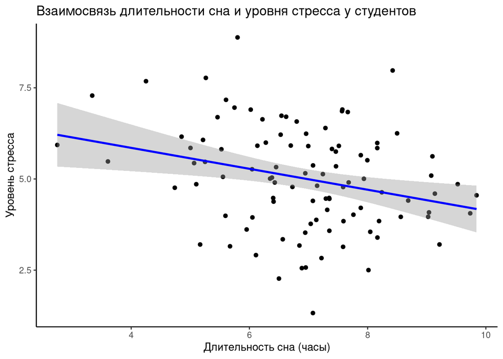

```r
library(ggplot2)
ggplot(df, aes(x = HoursOfSleep, y = StressLevel)) +
  geom_point()  +
  labs(
    title = "Взаимосвязь длительности сна и уровня стресса у студентов",
    x = "Длительность сна (часы)",
    y = "Уровень стресса"
  )+
  geom_smooth(method = "lm", color = "blue") +
  theme_classic()
```

Таким образом, мы видим значимую ассоциацию между уровнем стресса и длительностью сна, она не очень сильная, но она существует. Это может быть практически значимо, если мы докажем причинно-следственную связь этой ассоциации, а пока мы просто понимаем, что такая ассоциация существует.